# Practical Machine Learning: Prediction of Weight Lifting Quality

Manuel Maturano

2026-03-13

# Executive Summary

This project aims to **predict the quality of weight lifting exercises** using data from accelerometers on the belt, forearm, arm, and dumbbell of six participants, from [Velloso et. al.](http://web.archive.org/web/20161224072740/http:/groupware.les.inf.puc-rio.br/har). Using a Random Forest model with 5-fold cross-validation, an accuracy of over 99% was achieved on an independent testing set. This report details the data cleaning process, exploratory analysis, and model validation that were performed.

# Data Preprocessing

The initial dataset comprises 19,622 observations across 160 variables. However, a significant portion of these features are either administrative or exhibit a high degree of missingness.

```r
# ---- Load libraries and training set ----
library(caret)
library(data.table)
library(corrplot)
library(ggplot2)

# Load the dataset
dt <- fread("[https://d396qusza40orc.cloudfront.net/predmachlearn/pml-training.csv](https://d396qusza40orc.cloudfront.net/predmachlearn/pml-training.csv)",
            na.strings = c("NA", "#DIV/0!", ""))

# Factorize outcome
dt[, classe := as.factor(classe)]

# Remove administrative and time-related variables
dt <- dt[, .SD, .SDcols = !c("V1", "user_name", "raw_timestamp_part_1",
                             "raw_timestamp_part_2", "cvtd_timestamp",
                             "new_window", "num_window")]

# Remove columns with more than 10% NAs
dt <- dt[, .SD, .SDcols = !colMeans(is.na(dt))[colMeans(is.na(dt)) > .1] |> names()]
```

## Outlier Removal

During exploratory analysis, a severe instrumental outlier was identified in the forearm sensors (likely a sensor malfunction). This observation was removed to ensure model stability.

```r
outlier_idx <- which.max(dt$accel_forearm_y)
dt <- dt[-outlier_idx]
```

After these transformations, the clean dataset was saved for reproducibility and faster loading in further steps:

```r
# Save the pre-processed dataset for reproducibility and faster loading
saveRDS(dt, "weight_lifting_clean.rds")
```

# Exploratory Data Analysis

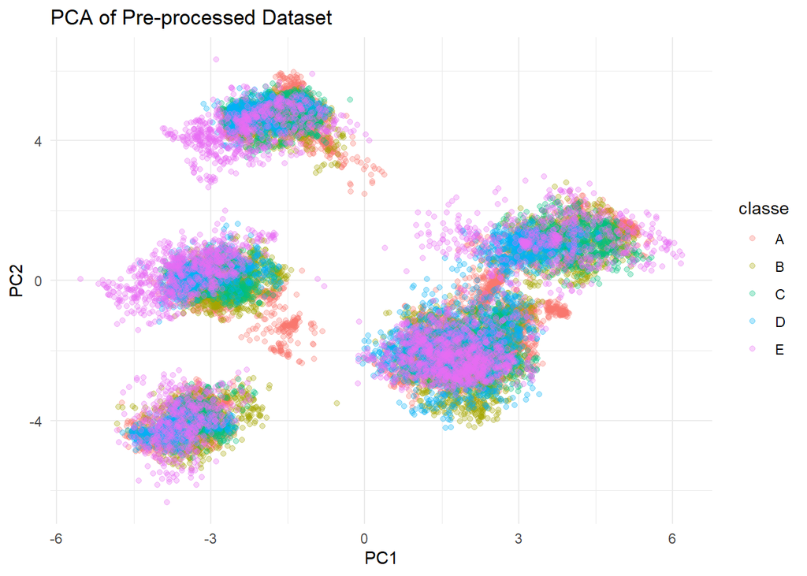

```r
# Import preprocessed dataset
dt <- readRDS("weight_lifting_clean.rds")

# Perform principal component analysis
pca_res <- prcomp(dt[, .SD, .SDcols = is.numeric], scale. = TRUE)
pca_data <- data.table(pca_res$x[, 1:2], classe = dt$classe)

ggplot(pca_data, aes(x = PC1, y = PC2, color = classe)) +
  geom_point(alpha = 0.3) +
  theme_minimal() +
  labs(title = "PCA of Pre-processed Dataset")
```

# Model Training

The data was split into a training set (75%) and a testing set (25%). A Random Forest algorithm was selected (using the ranger implementation) due to its ability to handle non-linear relationships and high-dimensional data without requiring feature scaling. To estimate performance and prevent overfitting, 5-fold Cross-Validation was employed.

```r
set.seed(1234)
inTrain <- createDataPartition(dt$classe, p = 0.75, list = FALSE)
training <- dt[inTrain, ]
testing  <- dt[-inTrain, ]

control <- trainControl(method = "cv", number = 5)
mod_rf <- train(classe ~ ., data = training, method = "ranger",
                trControl = control, importance = "impurity")

# Save the model
saveRDS(mod_rf, "rf_model_ranger.rds")
```

# Results and Out-of-Sample Error

The model was validated using the hold-out testing set. The confusion matrix indicates exceptional performance.

```r
mod_rf <- readRDS("rf_model_ranger.rds")

predictions <- predict(mod_rf, testing)
conf_matrix <- confusionMatrix(predictions, testing$classe)
print(conf_matrix$overall[1:2])
```

```
##  Accuracy     Kappa
## 0.9963288 0.9953561
```

The estimated Out-of-Sample Error is calculated as $1 - Accuracy$.Based on the testing set results:
$$Error = 1 - 0.996 = 0.004 \text{
(0.4%)}$$

# Variable Importance

The most influential predictors for exercise classification are primarily sensors located on the belt and the dumbbell, suggesting these areas capture the most variance in movement quality.

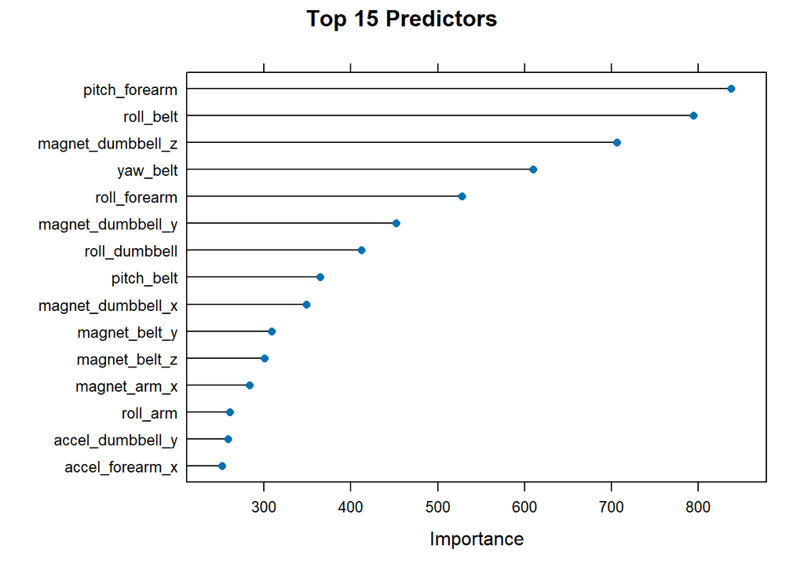

```r
var_imp <- varImp(mod_rf, scale = FALSE)
plot(var_imp, top = 15, main = "Top 15 Predictors")
```

# Final Predictions

The model was applied to the 20 test cases for the final quiz, successfully identifying the exercise quality for all instances.

```r
final_test <- fread("https://d396qusza40orc.cloudfront.net/predmachlearn/pml-testing.csv",
                    na.strings = c("NA", "#DIV/0!", ""))

final_test_clean <- final_test[, .SD, .SDcols = names(training)[-which(names(training) == "classe")]]

final_preds <- predict(mod_rf, final_test_clean)

results <- data.frame(
  problem_id = final_test$problem_id,
  prediction = final_preds
)

print(results)
```

```
##    problem_id prediction
## 1           1          B
## 2           2          A
## 3           3          B
## 4           4          A
## 5           5          A
## 6           6          E
## 7           7          D
## 8           8          B
## 9           9          A
## 10         10          A
## 11         11          B
## 12         12          C
## 13         13          B
## 14         14          A
## 15         15          E
## 16         16          E
## 17         17          A
## 18         18          B
## 19         19          B
## 20         20          B
```